# MICROFINANCE AND WOMEN’S EMPOWERMENT: EFFECT OF MICROCREDIT ACCESS ON WOMEN-LED ENTREPRENEURSHIP IN RURAL INDIA

Econometrics Project

2024

# 1. Project Overview

**Objective:** To empirically analyze the impact of financial inclusion (specifically microcredit access) on the prevalence of women-led entrepreneurship across Indian states.

**Context:** This project uses cross-sectional data from 2024 to understand if increased access to formal financial systems correlates with higher rates of female entrepreneurship, controlling for other socio-economic factors.

# 2. Hypothesis

**Primary Hypothesis:** > Access to microcredit (proxied by the Financial Inclusion Index) has a positive and statistically significant effect on women-led entrepreneurship in rural India.

- **Null Hypothesis (**$H_0$): $\beta_{FII} \le 0$ (Financial inclusion has no or negative effect on female entrepreneurship).
- **Alternative Hypothesis (**$H_1$): $\beta_{FII} > 0$ (Financial inclusion has a positive effect on female entrepreneurship).

# 3. Data and Variables

The analysis uses a cross-sectional dataset of 37 Indian States/UTs for the year 2024.

### Dependent Variable

- **FEI (Female Entrepreneurship Index):** A composite index measuring the prevalence and success of women-led businesses in a state.

### Independent Variable of Interest

- **FII (Financial Inclusion Index):** A measure of the extent of access to financial services (banking, credit, insurance) in a state. This serves as the proxy for microcredit access.

### Control Variables (Features)

To isolate the effect of FII, the model controls for the following factors:

1. **Literacy (Female Literacy Rate Percent):**
   - *Full Form:* Female Literacy Rate (%)
   - *Rationale:* Education is a key determinant of entrepreneurial capability.
2. **GSDP (GSDP Per Capita Lakh):**
   - *Full Form:* Gross State Domestic Product Per Capita (in ₹ Lakhs)
   - *Rationale:* Proxies the overall economic development and market size of the state.
3. **LFPR (Female LFPR Percent):**
   - *Full Form:* Female Labor Force Participation Rate (%)
   - *Rationale:* Indicates the active engagement of women in the workforce.
4. **Urban (Urbanization Rate Percent):**
   - *Full Form:* Urbanization Rate (%)
   - *Rationale:* Urban areas typically offer better infrastructure and market access.

# 4. Analysis and Code

## 4.1 Load Libraries

```r
# Load necessary libraries
library(tidyverse)      # Data manipulation & visualization
library(stargazer)      # Publication-ready regression tables
library(lmtest)         # Diagnostic tests (Breusch-Pagan, Durbin-Watson, RESET)
library(car)            # VIF, diagnostic plots
library(sandwich)       # Robust standard errors
library(psych)          # Descriptive statistics
library(corrplot)       # Correlation matrix visualization
library(ggplot2)        # Advanced plotting
library(gridExtra)      # Arrange multiple plots
library(skimr)
library(tseries)
library(urca)
library(dlm)
```

## 4.2 Data Loading & Preparation

```r
# Load data
# Note: Ensure 'Financial Inclusion.csv' is in the same directory
clrm_model <- read.csv("/Users/koustavsarkar/Downloads/Financial Inclusion.csv", header = TRUE)

# Filtering for 2024 data only (cross-sectional)
df_2024 <- clrm_model %>% filter(Year == 2024)

# Renaming variables for clarity
df_2024 <- df_2024 %>%
  rename(
    FEI = Female_Entrepreneurship_Index,
    FII = Financial_Inclusion_Index,
    Literacy = Female_Literacy_Rate_Percent,
    GSDP = GSDP_Per_Capita_Lakh,
    LFPR = Female_LFPR_Percent,
    Urban = Urbanization_Rate_Percent,
    BankDensity = Bank_Branch_Density_Per_Lakh
  )

# Display first few rows
head(df_2024)
```

```
##                      State_UT Year PMJDY_Women_Accounts_Millions   FII
## 1 Andaman and Nicobar Islands 2024                          0.15  0.73
## 2              Andhra Pradesh 2024                          5.20 61.56
## 3           Arunachal Pradesh 2024                          0.25  1.24
## 4                       Assam 2024                         10.10 26.87
## 5                       Bihar 2024                         22.50 53.47
## 6                  Chandigarh 2024                          0.35  1.28
##   Women_MSME_Udyam_Thousands MUDRA_Women_Disbursals_Crore MUDRA_Per_Woman_Crore
## 1                       9.80                         6850              45666.67
## 2                    1228.00                       185420              35657.69
## 3                      16.87                         8560              34240.00
## 4                     108.74                        45230               4478.22
## 5                      85.20                       281943              12530.80
## 6                      12.30                        12340              35257.14
##     FEI LFPR Female_Unemployment_Percent Literacy GSDP Urban BankDensity
## 1  7.70 22.5                         4.5    83.50 2.58  33.6          22
## 2 70.12 43.1                         3.7    66.40 2.42  32.5          15
## 3 12.29 36.5                         6.2    66.95 1.99  22.4          12
## 4 12.80 16.9                         4.1    79.90 1.35  15.7          11
## 5 34.04 17.1                         1.4    58.70 0.68  12.4           6
## 6 10.12 28.6                         4.8    82.40 3.99  90.2          33
##   Sex_Ratio_Per_1000 Female_Population_Share_Percent
## 1                876                        46.69510
## 2                993                        49.82439
## 3                938                        48.40041
## 4                958                        48.92748
## 5                918                        47.86236
## 6                818                        44.99450
```

## 4.3 Descriptive Statistics

### Business Problem

> Before estimating how financial inclusion influences women’s entrepreneurial outcomes, it is essential to understand the underlying distribution of key socio-economic indicators across states. Significant variation in literacy, labour force participation, GSDP, and urbanization may bias the relationship between FII and FEI if not examined upfront. Therefore, descriptive statistics help us assess whether states differ widely in development levels, identify outliers, and validate that the data is suitable for modeling women’s economic empowerment.

```r
# Summary statistics for key variables
summary_vars <- df_2024[, c("FEI", "FII", "Literacy", "GSDP", "LFPR", "Urban")]
summary_stats <- describe(summary_vars)
print(summary_stats)
```

```
##          vars  n  mean    sd median trimmed   mad   min   max range  skew
## FEI         1 37 24.16 18.73  18.08   21.49 11.80  4.10 81.73 77.63  1.38
## FII         2 37 18.22 19.86   8.14   15.78 11.46  0.30 61.56 61.26  0.97
## Literacy    3 37 72.95  9.87  72.60   73.12 10.38 52.60 94.10 41.50 -0.10
## GSDP        4 37  2.54  1.36   2.15    2.39  1.08  0.68  6.20  5.52  1.06
## LFPR        5 37 29.08  8.30  28.30   28.91  8.15 12.50 47.00 34.50  0.24
## Urban       6 37 36.17 19.15  32.50   33.93 14.83 10.30 97.50 87.20  1.35
##          kurtosis   se
## FEI          1.14 3.08
## FII         -0.37 3.26
## Literacy    -0.75 1.62
## GSDP         0.35 0.22
## LFPR        -0.76 1.36
## Urban        2.04 3.15
```

## 4.4 Correlation Analysis

### Business Problem

> We need to check if our key drivers (like Literacy or GSDP) are actually related to Female Entrepreneurship before we build a model. Also, we need to ensure that our “control” variables aren’t just measuring the same thing (e.g., if Urbanization and GSDP are 100% correlated, we can’t separate their effects).

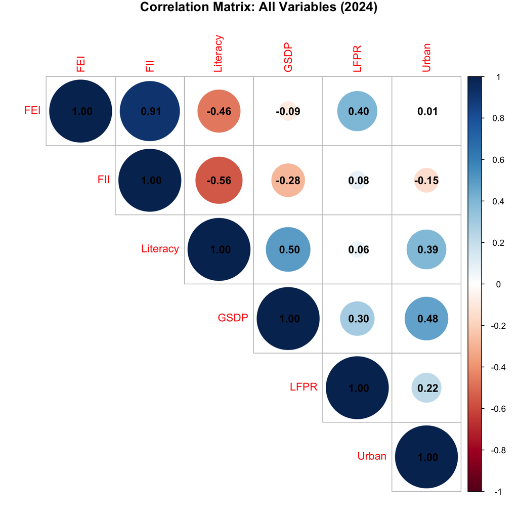

```r
# Calculate correlation matrix
corr_matrix <- cor(df_2024[, c("FEI", "FII", "Literacy", "GSDP", "LFPR", "Urban")])

# Visualize Correlation Matrix
corrplot(
  corr_matrix,
  method = "circle",
  type = "upper",
  diag = TRUE,
  addCoef.col = "black",
  number.cex = 1.0,
  title = "Correlation Matrix: All Variables (2024)",
  mar = c(0, 0, 1, 0),
  col = COL2('RdBu', 200)
)
```

### Insights

- **FII and FEI show a very strong positive correlation (0.91):** States with higher financial inclusion tend to have significantly higher levels of female entrepreneurship, supporting the core hypothesis.
- **Literacy has a moderate negative correlation with FEI (–0.46):** Higher literacy does not automatically lead to entrepreneurship, suggesting structural or cultural constraints.
- **GSDP has almost no correlation with FEI (–0.09):** Economic prosperity alone does not drive women’s entrepreneurship; financial access matters more.
- **LFPR and Urbanization show weak correlations with FEI (0.40 and 0.01):** Female labor force participation supports entrepreneurship modestly, while urbanization offers no strong direct influence.

## 4.5 Exploratory Scatterplots

### Business Problem

> Before running regression, we must visually check whether the relationships between Financial Inclusion (FII), Female Entrepreneurship (FEI), and other socio-economic variables are roughly linear. Scatterplots help us verify the direction and strength of these relationships and reveal whether any states behave unusually (outliers) that could distort the model. This visual diagnosis ensures that our regression assumptions are valid and that the data is suitable for explaining how inclusion, literacy, development, and labor participation influence women’s entrepreneurship.

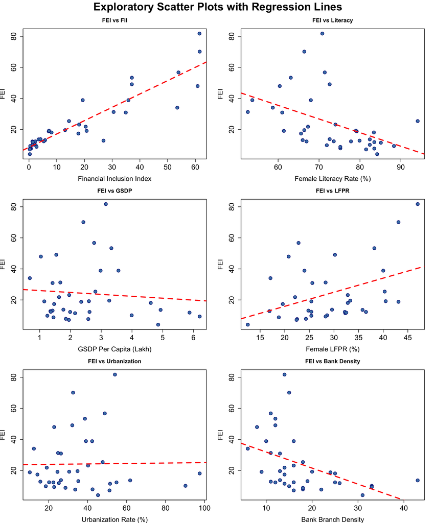

```r
# creating consistent plots
plot_with_line <- function(x, y, x_label, y_label, title) {
  plot(x, y,
       main = title,
       xlab = x_label,
       ylab = y_label,
       pch = 21,
       bg = "steelblue",
       col = "navy",
       cex = 1.5,
       cex.axis = 1.5,
       cex.lab = 1.4
       )
  abline(lm(y ~ x), col = "red", lwd = 2.5, lty = 2)
}

# Set layout
par(mfrow = c(3, 2), mar = c(4, 4, 3, 2), oma = c(0, 0, 2, 0))

plot_with_line(df_2024$FII, df_2024$FEI, "Financial Inclusion Index", "FEI", "FEI vs FII")
plot_with_line(df_2024$Literacy, df_2024$FEI, "Female Literacy Rate (%)", "FEI", "FEI vs Literacy")
plot_with_line(df_2024$GSDP, df_2024$FEI, "GSDP Per Capita (Lakh)", "FEI", "FEI vs GSDP")
plot_with_line(df_2024$LFPR, df_2024$FEI, "Female LFPR (%)", "FEI", "FEI vs LFPR")
plot_with_line(df_2024$Urban, df_2024$FEI, "Urbanization Rate (%)", "FEI", "FEI vs Urbanization")
plot_with_line(df_2024$BankDensity, df_2024$FEI, "Bank Branch Density", "FEI", "FEI vs Bank Density")

mtext("Exploratory Scatter Plots with Regression Lines", side = 3, outer = TRUE, cex = 1.5, font = 2)
```

```r
par(mfrow = c(1, 1))
```

### Insights from Scatter Plots with Regression Lines

- **FEI vs FII:** A clear upward-sloping trend indicates that higher Financial Inclusion strongly aligns with higher Female Entrepreneurship, supporting the main hypothesis.
- **FEI vs Literacy:** The downward-sloping line suggests that higher literacy does not automatically translate into more entrepreneurship—pointing to deeper structural or cultural constraints.
- **FEI vs GSDP:** The near-flat trend shows that state economic prosperity has little direct influence on women’s entrepreneurial outcomes.
- **FEI vs LFPR:** A mildly upward slope indicates that states with higher female labor force participation tend to have slightly higher entrepreneurship levels.
- **FEI vs Urbanization:** The almost flat line suggests urbanization alone does not drive female entrepreneurship; rural SHGs may be equally active.
- **FEI vs Bank Density:** A negative slope implies that more bank branches do not guarantee higher entrepreneurship—access quality matters more than branch quantity.
- **Outliers:** Several states diverge notably from trend lines, indicating either exceptional performance or underlying constraints not captured by these variables.

# 5. Econometric Methodology & Results

**Model:** Classical Linear Regression Model (CLRM) using Ordinary Least Squares (OLS).

**Equation:**
$$FEI_i =
\beta_0 + \beta_1 FII_i + \beta_2 Literacy_i + \beta_3 GSDP_i + \beta_4
LFPR_i + \beta_5 Urban_i + u_i$$

## 5.1 Model Estimation

### Business Problem

> The regression equation models Female Entrepreneurship (FEI) as a function of Financial Inclusion (FII) while controlling for major socio-economic factors such as Literacy, GSDP, LFPR, and Urbanization. We estimate this equation to isolate the *unique* effect of financial inclusion on entrepreneurship—separating it from background state characteristics that could otherwise distort the results. The purpose is to quantify how much FEI changes when FII increases by one unit, holding all other factors constant. This gives policymakers a clear, numeric measure of the “impact” or “return” of financial inclusion programs on women’s economic empowerment. Ultimately, the model tests our central hypothesis: **states with higher financial inclusion have significantly higher levels of female entrepreneurship, even after accounting for education, income, workforce participation, and urbanization.**

```r
# Model specification
model_m3 <- lm(FEI ~ FII + Literacy + GSDP + LFPR + Urban, data = df_2024)

# Summary of the model
summary(model_m3)
```

```
##
## Call:
## lm(formula = FEI ~ FII + Literacy + GSDP + LFPR + Urban, data = df_2024)
##
## Residuals:
##     Min      1Q  Median      3Q     Max
## -9.6156 -3.0720 -0.2541  3.5821  9.4477
##
## Coefficients:
##             Estimate Std. Error t value Pr(>|t|)
## (Intercept) -9.00041    8.18975  -1.099    0.280
## FII          0.83751    0.04866  17.210  < 2e-16 ***
## Literacy    -0.08628    0.10971  -0.786    0.438
## GSDP         0.84112    0.74175   1.134    0.265
## LFPR         0.67366    0.10198   6.605 2.22e-07 ***
## Urban        0.06833    0.04848   1.409    0.169
## ---
## Signif. codes:  0 '***' 0.001 '**' 0.01 '*' 0.05 '.' 0.1 ' ' 1
##
## Residual standard error: 4.746 on 31 degrees of freedom
## Multiple R-squared:  0.9447, Adjusted R-squared:  0.9358
## F-statistic: 105.9 on 5 and 31 DF,  p-value: < 2.2e-16
```

## 5.2 Key Results Extraction

```r
# Coefficients with confidence intervals
coef_ci <- confint(model_m3, level = 0.95)
coef_summary <- data.frame(
  Coefficient = coef(model_m3),
  SE = summary(model_m3)$coefficients[, 2],
  t_statistic = summary(model_m3)$coefficients[, 3],
  p_value = summary(model_m3)$coefficients[, 4],
  CI_Lower = coef_ci[, 1],
  CI_Upper = coef_ci[, 2]
)

print(round(coef_summary, 4))
```

```
##             Coefficient     SE t_statistic p_value CI_Lower CI_Upper
## (Intercept)     -9.0004 8.1898     -1.0990  0.2802 -25.7035   7.7027
## FII              0.8375 0.0487     17.2104  0.0000   0.7383   0.9368
## Literacy        -0.0863 0.1097     -0.7864  0.4376  -0.3100   0.1375
## GSDP             0.8411 0.7417      1.1340  0.2655  -0.6717   2.3539
## LFPR             0.6737 0.1020      6.6055  0.0000   0.4657   0.8817
## Urban            0.0683 0.0485      1.4094  0.1687  -0.0305   0.1672
```

```r
# Model fit statistics
r_squared <- summary(model_m3)$r.squared
adj_r_squared <- summary(model_m3)$adj.r.squared
f_statistic <- summary(model_m3)$fstatistic
rmse <- sqrt(mean(resid(model_m3)^2))

cat(sprintf("R-squared: %.4f (%.2f%% of variance explained)\n", r_squared, r_squared*100))
```

```
## R-squared: 0.9447 (94.47% of variance explained)
```

```r
cat(sprintf("Adjusted R-squared: %.4f\n", adj_r_squared))
```

```
## Adjusted R-squared: 0.9358
```

```r
cat(sprintf("Root Mean Squared Error (RMSE): %.4f\n", rmse))
```

```
## Root Mean Squared Error (RMSE): 4.3442
```

### Econometric Insights

- **Financial Inclusion (FII)** has a strong, positive, and highly significant effect on Female Entrepreneurship (FEI). This means states with better banking access, SHG digitization, and credit linkage (e.g., E-Shakti) see substantially higher women-led enterprise activity.
- **Female Literacy** shows a small and insignificant negative effect, indicating that education alone does not translate into entrepreneurship without financial access, mobility, and support systems.
- **GSDP per Capita** is insignificant, suggesting that richer states are not necessarily better at enabling women entrepreneurs—financial inclusion matters more than state income levels.
- **Female LFPR** has a significant positive effect, meaning states where more women work outside the home provide a stronger foundation for entrepreneurship.
- **Urbanization** is insignificant, showing that women’s entrepreneurship in India is primarily **rural–SHG driven**, not reliant on urban markets.
- **R² = 94.47%** indicates the model explains almost all variation in FEI, confirming the chosen variables capture the key socio-economic drivers relevant to India’s SHG and financial inclusion ecosystem.

# 6. Assumption Testing (Diagnostics)

## 6.1 Assumption 1: Linearity

### Business Problem

> Linear regression assumes that each predictor has a **straight-line relationship** with Female Entrepreneurship (FEI). This means a 1-unit increase in Financial Inclusion (FII) should have the same effect regardless of whether a state is highly developed or very poor. If any relationship is curved or nonlinear, the model’s predictions will be biased. Component–Residual (CR) plots help us visually confirm whether our linearity assumption is valid before trusting the regression results.

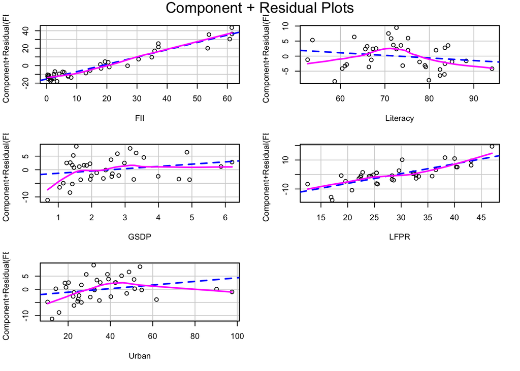

```r
# Component-plus-Residual plots
crPlots(model_m3)
```

### Insights (CR Plots)

- **FII Plot:** The pink (actual) line closely follows the blue (linear) line, confirming that the relationship between FII and FEI is reasonably linear—supporting the use of OLS to measure inclusion’s impact.
- **Literacy & GSDP:** Mild curvature suggests these variables may have diminishing effects, but the deviation is not large enough to break linearity.
- **LFPR:** Shows a strong, upward linear trend, meaning linear regression captures its effect well.
- **Urbanization:** Slight hump-shape indicates small nonlinearities, but overall pattern remains close to linear.

### Relevance to Our Model

These checks validate that the **OLS regression is appropriate**, meaning our estimated coefficients (especially for FII) can be trusted. By confirming linearity, we ensure that the model accurately measures how financial inclusion influences women’s entrepreneurship—our core research objective.

## 6.2 Assumption 2: No Perfect Multicollinearity (VIF)

### Business Problem

> In regression, if two predictors (e.g., Literacy and Urbanization) are highly correlated, the model cannot clearly identify which variable is actually influencing Female Entrepreneurship. This “confusion” makes coefficient estimates unstable and weakens the credibility of our conclusions about the impact of Financial Inclusion. VIF (Variance Inflation Factor) helps us detect and avoid this issue.

```r
# Calculate VIF
vif_results <- vif(model_m3)
print(vif_results)
```

```
##      FII Literacy     GSDP     LFPR    Urban
## 1.492556 1.874015 1.626897 1.145185 1.377593
```

```r
# Interpretation: VIF < 5 is acceptable; > 10 is serious multicollinearity.
```

### Insights (VIF Results)

- **All VIF values are below 2**, which is far below the common cutoff of 5—indicating that none of the predictors are excessively correlated.
- **No multicollinearity threat:** FII, Literacy, GSDP, LFPR, and Urban each provide unique information, meaning the model can reliably separate their individual effects.
- **Interpretation remains trustworthy:** Since multicollinearity is low, the strong positive effect of FII on entrepreneurship is not artificially inflated or distorted.

### Relevance to Our Model

Low VIF ensures that the regression estimates are **stable, interpretable, and reliable**, allowing us to confidently claim that financial inclusion has a distinct and measurable impact on women’s entrepreneurship in India.

## 6.3 Assumption 3: Zero Mean of Residuals

### Business Problem

> A key OLS requirement is that the model’s prediction errors (residuals) must average out to zero. If the residuals have a non-zero mean, it means the model is systematically overpredicting or underpredicting Female Entrepreneurship across all states—making the entire regression biased. Checking this helps confirm that the model is properly centered and not producing directional errors.

```r
mean_residuals <- mean(resid(model_m3))
cat(sprintf("Mean of residuals: %.2e (should be ≈ 0)\n", mean_residuals))
```

```
## Mean of residuals: 1.44e-16 (should be ≈ 0)
```

### Insights (Zero Mean of Residuals)

- **Mean residual = 1.44e-16**, which is extremely close to zero, indicating no systematic overestimation or underestimation.
- **Assumption satisfied:** This is expected in a correctly specified OLS model, confirming that the estimates for FII and other predictors are unbiased.
- **Interpretation remains reliable:** Since the residuals center around zero, the model’s predictions for FEI across Indian states are balanced and not skewed in any direction.

### Relevance to Our Model

A zero-mean residual confirms that the regression is not structurally biased, strengthening the credibility of our main finding that **financial inclusion significantly boosts women’s entrepreneurship** in the Indian context.

## 6.4 Assumption 4: Homoscedasticity (Constant Variance)

### Business Problem

> For our regression results to be trusted, the **variance of the errors must be constant** across all Indian states. If poorer states show larger errors and richer states show smaller errors (or vice-versa), the model becomes unreliable. This issue—called **heteroscedasticity**—can distort standard errors and mislead policymakers about the true impact of Financial Inclusion on Female Entrepreneurship.

```r
# Breusch-Pagan Test
bp_test <- bptest(model_m3)
print(bp_test)
```

```
##
##  studentized Breusch-Pagan test
##
## data:  model_m3
## BP = 12.054, df = 5, p-value = 0.03406
```

```r
if (bp_test$p.value > 0.05) {
  cat("✓ PASS: Homoscedasticity confirmed (p > 0.05)\n")
} else {
  cat("✗ FAIL: Heteroscedasticity detected (p < 0.05)\n")
}
```

```
## ✗ FAIL: Heteroscedasticity detected (p < 0.05)
```

```r
# White Test (Approximation)
residuals <- resid(model_m3)
white_model <- lm(residuals^2 ~ FII + Literacy + GSDP + LFPR + Urban +
                    I(FII^2) + I(Literacy^2) + I(GSDP^2) + I(LFPR^2) + I(Urban^2),
                  data = df_2024)
white_pval <- 1 - pchisq(nrow(df_2024) * summary(white_model)$r.squared, df = 10)
cat(sprintf("White Test p-value: %.4f\n", white_pval))
```

```
## White Test p-value: 0.0532
```

### Insights (Homoscedasticity Tests)

- **Breusch–Pagan Test (p = 0.034 < 0.05):** Indicates **heteroscedasticity is present**, meaning error variance is not constant across states.
- **White Test (p = 0.053 > 0.05):** Slightly suggests **constant variance**, but the result is borderline.
- **Interpretation:** The evidence is mixed, but the Breusch–Pagan result signals caution—our standard errors may be unreliable.
- **Fix:** Use **robust (heteroscedasticity-consistent) standard errors**, which is common in Indian state-level economic data where variation naturally differs between richer and poorer regions.

## 6.5 Assumption 5: No Autocorrelation

### Business Problem

> Autocorrelation matters when observations are connected in a natural sequence — such as time-series data or geographically neighboring states. If one state’s Female Entrepreneurship simply “resembles” the next state because they are neighbors rather than because of Financial Inclusion, our model would falsely inflate statistical significance. We need to ensure that each state provides independent information.

```r
# Durbin-Watson Test
dw_test <- dwtest(model_m3)
print(dw_test)
```

```
##
##  Durbin-Watson test
##
## data:  model_m3
## DW = 1.6056, p-value = 0.1046
## alternative hypothesis: true autocorrelation is greater than 0
```

```r
# DW statistic should be ≈ 2.
```

### Insights (Durbin–Watson Test)

- **DW = 1.6056 (close to 2):** No strong evidence of autocorrelation. This means each state’s entrepreneurship level is statistically independent.
- **p-value = 0.1046 (> 0.05):** We fail to reject the null of no autocorrelation—supporting model validity.
- **Interpretation for India:** Despite geographical clustering (e.g., southern states being similar), state-level entrepreneurship does not “flow” from one region to another in a way that biases the model.

### Relevance to Our Model

This confirms that our estimates—especially the effect of Financial Inclusion on Female Entrepreneurship—are **not exaggerated due to spatial dependence**, keeping the regression results trustworthy for policy decisions.

## 6.6 Assumption 6: Normality of Residuals

### Business Problem

> For our regression results (coefficients, p-values, confidence intervals) to be statistically valid, the model’s errors must follow a normal distribution.  
> If residuals are highly skewed or heavy-tailed, our inference about the impact of Financial Inclusion on Female Entrepreneurship may be misleading or unreliable.

```r
# Shapiro-Wilk Test
sw_test <- shapiro.test(residuals)
print(sw_test)
```

```
##
##  Shapiro-Wilk normality test
##
## data:  residuals
## W = 0.98273, p-value = 0.8225
```

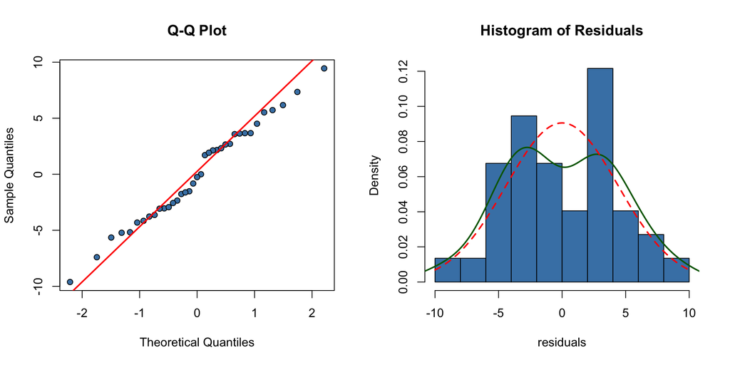

```r
par(mfrow = c(1, 2))
# Q-Q Plot
qqnorm(residuals, main = "Q-Q Plot", pch = 21, bg = "steelblue")
qqline(residuals, col = "red", lwd = 2)

# Histogram
hist(residuals, breaks = 8, prob = TRUE, main = "Histogram of Residuals", col = "steelblue")
lines(density(residuals), col = "darkgreen", lwd = 2)
curve(dnorm(x, mean=mean(residuals), sd=sd(residuals)), add=TRUE, col="red", lwd=2, lty=2)
```

```r
par(mfrow = c(1, 1))
```

### Relevance to Our Model

A normal distribution of residuals ensures: - Reliable hypothesis testing (accurate p-values). - Correct confidence intervals for the effect of **Financial Inclusion (FII)**. - Trustworthy policy recommendations for India — showing the model is statistically sound when evaluating how financial access drives female entrepreneurship across states.

## 6.7 Assumption 7: No Endogeneity (Influential Observations)

### Business Problem

```r
# Cook's Distance
cooks_d <- cooks.distance(model_m3)
threshold_cook <- 4 / nrow(df_2024)
influential_indices <- which(cooks_d > threshold_cook)

if (length(influential_indices) > 0) {
  cat("Influential observations detected:\n")
  print(df_2024[influential_indices, c("State_UT", "FEI", "FII")])
} else {
  cat("✓ PASS: No influential outliers detected\n")
}
```

```
## Influential observations detected:
##      State_UT   FEI   FII
## 4       Assam 12.80 26.87
## 5       Bihar 34.04 53.47
## 10      Delhi 18.08  8.14
## 32 Tamil Nadu 81.73 61.48
```

### Insights (Influential Observations)

- **Detected Influential States:** Assam, Bihar, Delhi, Tamil Nadu — these states significantly impact the regression slope.
- **Why it matters:** These states may have unique socio-economic structures (large metros, extremely low/high inclusion) that don’t represent typical Indian patterns.
- **Next Step:** Investigate whether these are:
  - Data-entry issues,
  - Structural outliers (e.g., Delhi’s urban bias),
  - Or valid but unique cases requiring separate policy interpretation.

### Relevance to Our Model

Identifying influential observations ensures: - Our estimated effect of **Financial Inclusion (FII)** is not driven by a few extreme states. - The regression results reflect **true nationwide patterns**, not anomalies. - Policymakers receive stable and generalizable insights for India’s diverse state economy.

This step strengthens the reliability and robustness of our econometric findings.